# PreliminaryEDA

Yan Gong & Xigang Zhang

04/07/2020

# Guiding Question (Research Question)

To identify the potential demographic risk factor towards drug use among 20-49 years old young adults. What is the potential risk of abuse of drug among these people in US?

# Acquainted with Data Sources

### Where did you find them?

NHANES Questionnaires, Datasets, and Related Documentation of National Health and Nutrition Examination Survey (NHANES)

Link: https://wwwn.cdc.gov/nchs/nhanes/default.aspx

### Who collected/maintains them?

National Center of Health Statistics (NCHS) under the Centers for Disease Control and Prevetion (CDC).

### When & Why were they originally collected?

They collected them from year 2017-2018. The reason for CDC collect the data is because NHANES is a stuides designed to asses the thealth and nutrional stauts of adults and children in the U.S the survey is unique in combining interviews with physical and lavoraatory examintations.

### What does a case represent in each data source, and how many total cases are available?

In demographic dataset (primary dataset), the case represents all the demographic information collected from each respondents in year 2017-2018, 9254 cases are available; in drug use dataset (other source data), the case represents all the factor (predictor) variables information collected from each respondents in year 2017-2018, 4572 cases are available.

# Intuition Related to the Research Question

### Informative plots and summary statistics

[output not shown]

[output cut: 32 more lines]

```r
demographic_20172018 <- read_dta("demographic_20172018.dta")
druguse_20172018 <- read_dta("druguse_20172018.dta")
# Generate Tables
demographic_20172018 %>%
  group_by(dmdfmsiz, ridreth3) %>%
  summarise(total = n())

druguse_20172018 %>%
  group_by(duq240) %>%
  summarise(total = n())
```

| duq240 | total |
| --- | --- |
| 1 | 671 |
| 2 | 3473 |
| 7 | 4 |
| 9 | 5 |
| NA | 419 |

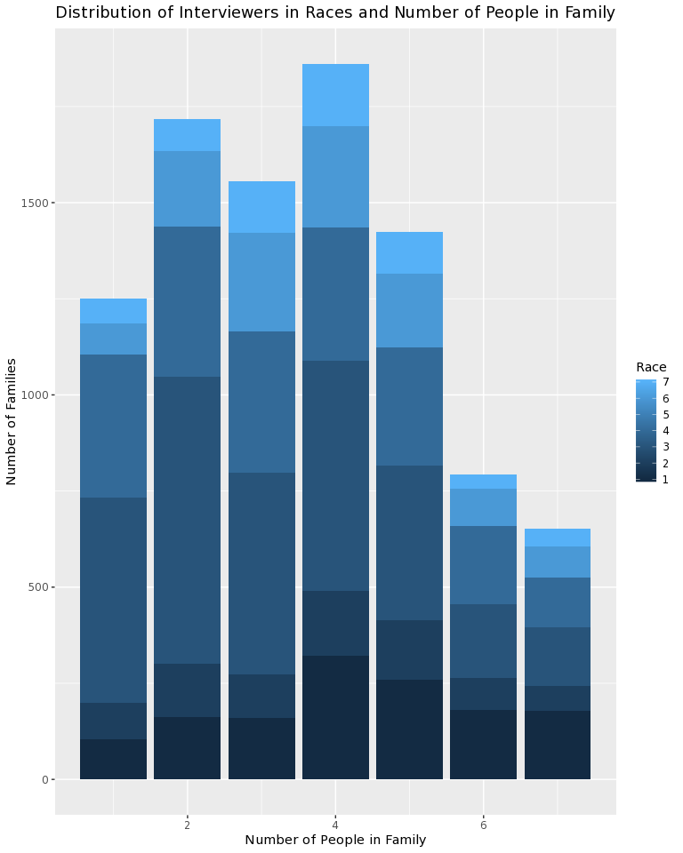

```r
# Generate plots
demographic_20172018 %>%
  group_by(dmdfmsiz, ridreth3) %>%
  summarise(total = n()) %>%
  ggplot(aes(x = dmdfmsiz, y = total, fill = ridreth3)) +
  geom_bar(stat = "identity") +
  labs(x = "Number of People in Family",
       y = "Number of Families",
       fill = "Race",
       title = "Distribution of Interviewers in Races and Number of People in Family")
```

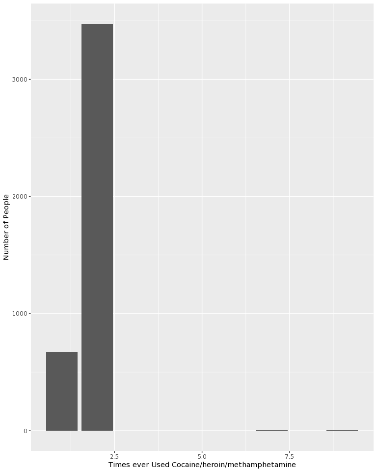

```r
druguse_20172018 %>%
  group_by(duq240) %>%
  summarise(total = n()) %>%
  ggplot(aes(x = duq240, y = total)) +
  geom_bar(stat = "identity") +
  labs(x = "Times ever Used Cocaine/heroin/methamphetamine",
       y = "Number of People")
```

### Preliminary observations and intuition about the research question

```r
# Merged dataset
merged_20172018 <- read_dta("merged_20172018.dta")
merged_20172018

# Inner join drug used and demographic datasets
druguse_20172018 %>%
  inner_join(demographic_20172018, by = c("seqn"))
```

[output not shown]

# Two Data Sources

### Primary data

The “demographic_20172018.dta” DTA file in the repository, which is the demographic data of NHANES 2017-2018.

Link: https://wwwn.cdc.gov/nchs/nhanes/search/datapage.aspx?Component=Demographics&CycleBeginYear=2017 (XPT Format)

### Other data sources

The “druguse_20172018.dta” DTA file in the repository, which is the drug use data of NHANES 2017-2018.

Link: https://wwwn.cdc.gov/nchs/nhanes/Search/DataPage.aspx?Component=Questionnaire&CycleBeginYear=2017 (XPT Format)